# Exploration of Loan Data from Prosper

## Dataset Overview

This data set contains 113,937 loans with 81 variables on each loan, including loan amount, borrower rate (or interest rate), current loan status, borrower income, and many others.

## Investigation Overview

Is there a relationship between specific variables and the status of a loan?

The huge dataset with a lot of informaton (81 variables) allows me to have deeper look at the question what factors affect a loan’s outcome status.

This is a very critical question for banks and loan companies in order to minimize the default risk and and to set the right interest rate (including setting a proper risk premium).

```python
# import all packages and set plots to be embedded inline
import numpy as np
import pandas as pd
import matplotlib.pyplot as plt
import seaborn as sns
import requests, io, os

%matplotlib inline
import warnings
warnings.filterwarnings("ignore")
```

```python
# load in the dataset & chaning the datatypes
loan_data_clean = pd.read_csv('loan_data_master.csv')

# Converting datatype to categorical
cols_cat = ['ProsperScore', 'Term', 'IncomeRange', 'LoanStatus', 'EmploymentStatus']

for i in cols_cat:
    loan_data_clean[i] = loan_data_clean[i].astype('category')

loan_data_clean.info()
```

```
<class 'pandas.core.frame.DataFrame'>
RangeIndex: 83397 entries, 0 to 83396
Data columns (total 14 columns):
 #   Column                      Non-Null Count  Dtype
---  ------                      --------------  -----
 0   ListingKey                  83397 non-null  object
 1   LoanStatus                  83397 non-null  category
 2   Term                        83397 non-null  category
 3   ProsperScore                83397 non-null  category
 4   EmploymentStatus            83397 non-null  category
 5   MonthlyLoanPayment          83397 non-null  float64
 6   Recommendations             83397 non-null  int64
 7   BorrowerAPR                 83397 non-null  float64
 8   BorrowerRate                83397 non-null  float64
 9   LoanOriginalAmount          83397 non-null  int64
 10  OpenCreditLines             83397 non-null  float64
 11  StatedMonthlyIncome         83397 non-null  float64
 12  TotalProsperPaymentsBilled  18970 non-null  float64
 13  IncomeRange                 83397 non-null  category
dtypes: category(5), float64(6), int64(2), object(1)
memory usage: 6.1+ MB
```

## Prosper Score and Loan Status

The Prosper Score seems to affect the outcome of the loan: most borrower have an Prosper Score of 8 when a loan is completed, while most borrower with defaulted and charged-off loans have an Prosper Score of 6. Furthermore, the most common Prosper Score for borrowers with loans that have past due payments is 4

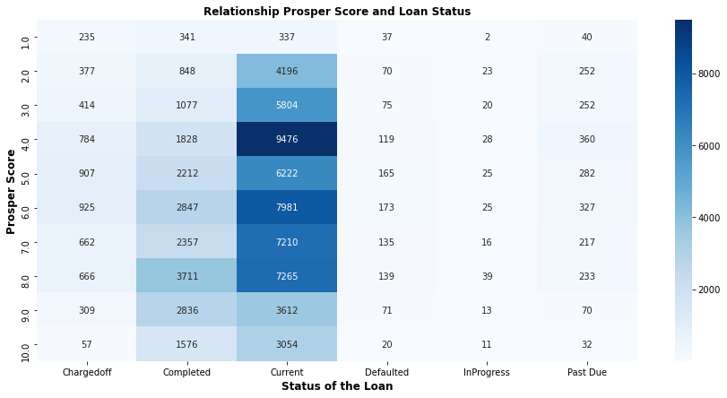

```python
ct_counts = loan_data_clean.groupby(['LoanStatus', 'ProsperScore']).size()
ct_counts = ct_counts.reset_index(name = 'count')
ct_counts = ct_counts.pivot(index = 'ProsperScore', columns = 'LoanStatus', values = 'count')
ct_counts

plt.figure(figsize = (15,7))
sns.heatmap(ct_counts, annot = True, fmt = 'd', cmap = 'Blues', mask = ct_counts.isnull())
plt.xlabel('Status of the Loan', fontweight = 'bold', fontsize = 12)
plt.ylabel('Prosper Score', fontweight = 'bold', fontsize = 12)
plt.title('Relationship Prosper Score and Loan Status', fontweight = 'bold', fontsize = 12);
```

## Interest Rate and Loan Status

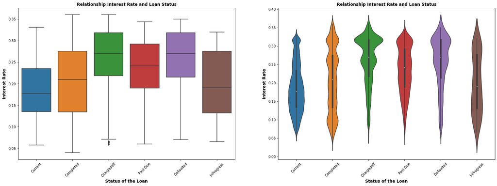

```python
plt.figure(figsize = (25, 18))

plt.subplot(221)
sns.boxplot(data = loan_data_clean, x = 'LoanStatus', y = 'BorrowerRate', order = loan_data_clean['LoanStatus'].value_counts().index)
plt.xticks(rotation=45)
plt.xlabel('Status of the Loan', fontweight = 'bold', fontsize = 12)
plt.ylabel('Interest Rate', fontweight = 'bold', fontsize = 12)
plt.title('Relationship Interest Rate and Loan Status', fontweight = 'bold', fontsize = 12)

plt.subplot(222)
sns.violinplot(data = loan_data_clean, x = 'LoanStatus', y = 'BorrowerRate', order = loan_data_clean['LoanStatus'].value_counts().index)
plt.xticks(rotation=45)
plt.xlabel('Status of the Loan', fontweight = 'bold', fontsize = 12)
plt.ylabel('Interest Rate', fontweight = 'bold', fontsize = 12)
plt.title('Relationship Interest Rate and Loan Status', fontweight = 'bold', fontsize = 12);
```

## Prosper Score and Loan Status in relation to the Interest Rate

The interest rate is as well correlated to the Prosper Score as to the Status of the loan: the higher the Prosper Score, the lower the interest rate, the lower the risk for Prosper that the loan will be defaulted, charged-off or has past due payments

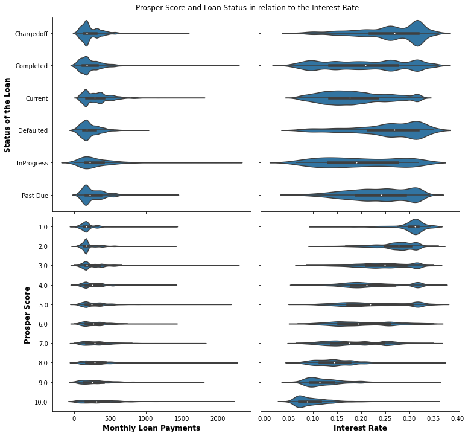

```python
g = sns.PairGrid(data = loan_data_clean, x_vars = ['MonthlyLoanPayment', 'BorrowerRate'],
                y_vars = ['LoanStatus','ProsperScore'], height = 5, aspect = 1)
g.map(sns.violinplot)
g.axes[1,0].set_xlabel('Monthly Loan Payments', fontweight = 'bold', fontsize = 12)
g.axes[1,1].set_xlabel('Interest Rate', fontweight = 'bold', fontsize = 12)
g.axes[0,0].set_ylabel('Status of the Loan', fontweight = 'bold', fontsize = 12)
g.axes[1,0].set_ylabel('Prosper Score', fontweight = 'bold', fontsize = 12)

plt.subplots_adjust(top=0.95)
g.fig.suptitle('Prosper Score and Loan Status in relation to the Interest Rate');
```